# Modelos Arma

Trabalho de Giovani Valdrighi e Vitória Guardieiro para a matéria de séries temporais.

```r
library(tseries)
```

```r
load("dados_arma_4.RData")

plot_acf_pacf <- function(series){
  par(mfrow = c(2, 1))
  acf(series, main = "ACF")
  pacf(series, main = "PACF")
}

plot_res <- function(res){
  plot(res, main = "Residuals of model",
       ylab = "Residual", type = "p")
  abline(0, 0)
}
```

# Modelos ARMA

Com 9 séries temporais, iremos avaliar cada uma delas e identificar se ela é gerada por um modelo AR(p), um modelo MA(q) ou um modelo ARMA(p, q). Em todas as diferentes séreis iremos inicialmente visualizar a série, a função de autocorrelação e a função de autocorrelação parcial.

## Série 1

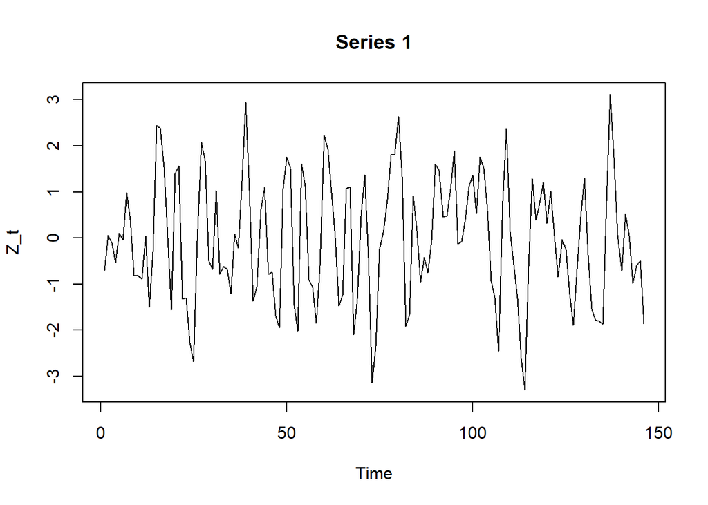

```r
plot(X[[1]], main = "Series 1", ylab = "Z_t")
```

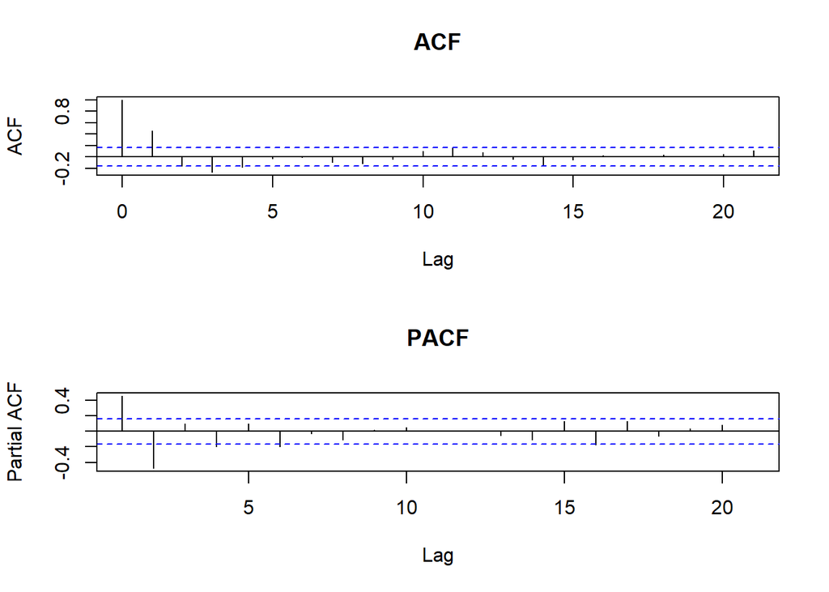

```r
plot_acf_pacf(X[[1]])
```

Vemos que a ACF e a PACF decrescem de forma brusca, tendo valores significativos para os dois primeiros lags, dessa forma, iremos considerar dois modelos, o modelo AR(2) e o modelo ARMA(2, 2). Vamos tentar fitar um modelo AR(2).

```r
model1 <- arma(X[[1]], order = c(2, 0))
summary(model1)
```

```
##
## Call:
## arma(x = X[[1]], order = c(2, 0))
##
## Model:
## ARMA(2,0)
##
## Residuals:
##     Min      1Q  Median      3Q     Max
## -2.3168 -0.7743  0.1256  0.6870  2.4984
##
## Coefficient(s):
##            Estimate  Std. Error  t value Pr(>|t|)
## ar1         0.68921     0.07292    9.451  < 2e-16 ***
## ar2        -0.48531     0.07289   -6.658 2.77e-11 ***
## intercept  -0.02129     0.08702   -0.245    0.807
## ---
## Signif. codes:  0 '***' 0.001 '**' 0.01 '*' 0.05 '.' 0.1 ' ' 1
##
## Fit:
## sigma^2 estimated as 1.113,  Conditional Sum-of-Squares = 159.18,  AIC = 435.98
```

Vamos visualizar inicialmente o modelo real e o previsto, e em sequência, o plot de resíduos.

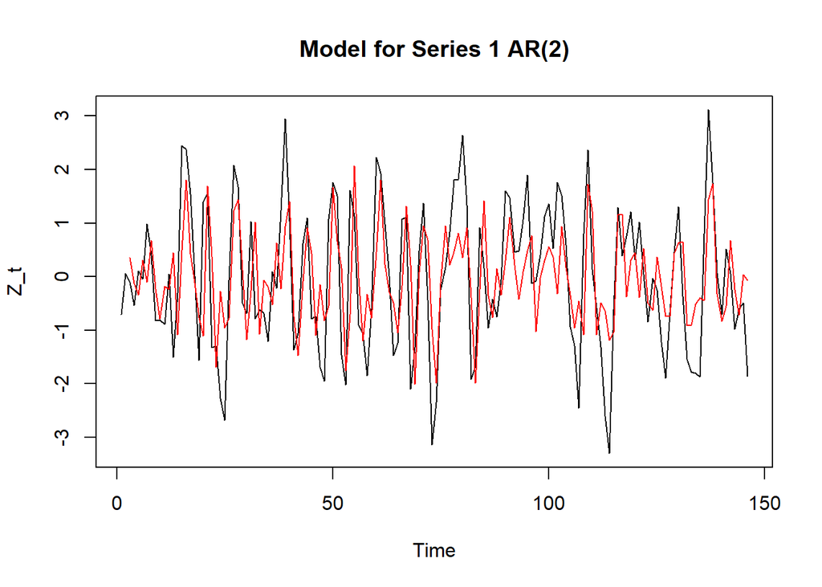

```r
plot(X[[1]], main = "Model for Series 1 AR(2)", ylab = "Z_t")
lines(model1$fitted.values, col = "red")
```

Realizando o mesmo procedimento, mas para o modelo ARMA(2, 2).

```r
model1 <- arma(X[[1]], order = c(2, 2))
summary(model1)
```

```
##
## Call:
## arma(x = X[[1]], order = c(2, 2))
##
## Model:
## ARMA(2,2)
##
## Residuals:
##        Min         1Q     Median         3Q        Max
## -2.1588765 -0.5967001  0.0001618  0.7185817  2.8350422
##
## Coefficient(s):
##            Estimate  Std. Error  t value Pr(>|t|)
## ar1        0.792873    0.133253    5.950 2.68e-09 ***
## ar2       -0.119687    0.107696   -1.111    0.266
## ma1        0.060935    0.110778    0.550    0.582
## ma2       -0.775825    0.116414   -6.664 2.66e-11 ***
## intercept -0.005245    0.024207   -0.217    0.828
## ---
## Signif. codes:  0 '***' 0.001 '**' 0.01 '*' 0.05 '.' 0.1 ' ' 1
##
## Fit:
## sigma^2 estimated as 0.9758,  Conditional Sum-of-Squares = 139.55,  AIC = 420.76
```